# Data Viz with ggplot2

Ryan Greenup

26/12/2019

# Specifying `groups`

## Load Packages

So first load any useful packages:

```r
load.pac <- function() {

  if(require('pacman')){
    library('pacman')
  }else{
    install.packages('pacman')
    library('pacman')
  }

  pacman::p_load(tidyverse, rmarkdown, plotly, colorspace, RColorBrewer, mise, formatR)

}

if (!exists("execFlag")) {
 load.pac()
  execFlag <- FALSE
}

mise()
```

```r
library(OpeninVim)
```

## Example Plot

So take a fairly ordinary plot from `mtcars`:

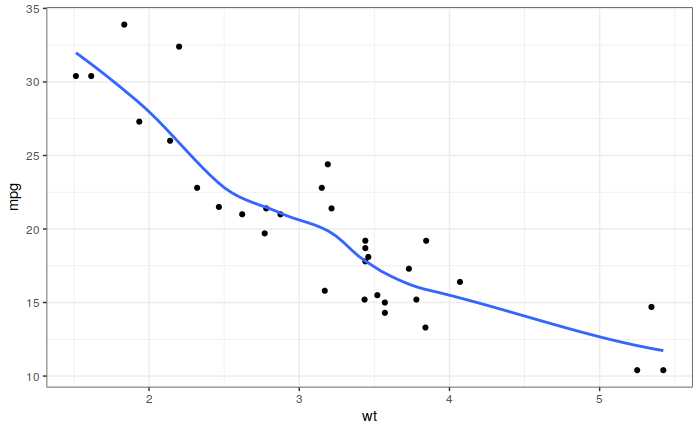

```r
library(colorspace)
library(tidyverse)
library(RColorBrewer)

# Plot 1: change the LOESS span
ggplot(mtcars, aes(x = wt, y = mpg)) +
  geom_point() +
  # Add span below
  geom_smooth(se = FALSE, span = 0.7) +
  theme_bw()
```

### Clustering

By looking at this plot it seems fairly obvious that there are three clusters, this could be visualised using Heirarchical Clustering:

[figure not shown]

```r
mcars <- as_tibble(mtcars)
mcars$cyl <- factor(mcars$cyl, levels = c(4,6,8), ordered = TRUE )
dst <- mcars %>% dist()
hc.iris.complete <- hclust(dst, method = 'complete')

#### 2. Cluster the observations using average and single linkage.
hc.iris.average  <- hclust(dst, method = 'average')
hc.iris.single   <- hclust(dst, method = 'single')

##### Plot the Predictions
#Now that the models have been made, by specifying the number of groups required, the function `cutree` will determine at what height to cut off the dendogram:

hcPreds <- cutree(hc.iris.complete, k = 3)

# Make the Data
groupPred <- factor(hcPreds, levels = c(1,2,3), ordered = FALSE)
mcars$KMpred <- groupPred

# Plot the Data
ggplot(mcars, aes(y = mpg, x = wt, col = KMpred)) +
  geom_point() +
  labs(col = "Predicted\nGroup", caption = "Ellipses represent 90% Normal confidence levels,\n
       predictions made using K-means algorithm with 3 classes") +
  stat_ellipse(level = 0.9) +
  theme_bw()
```

## Seperate Models

In order to accomodate the multiple models it would be desirable to make seperate plots for the clusters, this could be acheived by simply asking `ggplot` to:

- make a linear model when the `col` variable is specified

But if we still wanted to fit a loess model across the entire model then we would need to set the group to 1:

- `stat_smooth(aes(group=1))`

So putting all that together (and substituting cylinder instead of clustering):

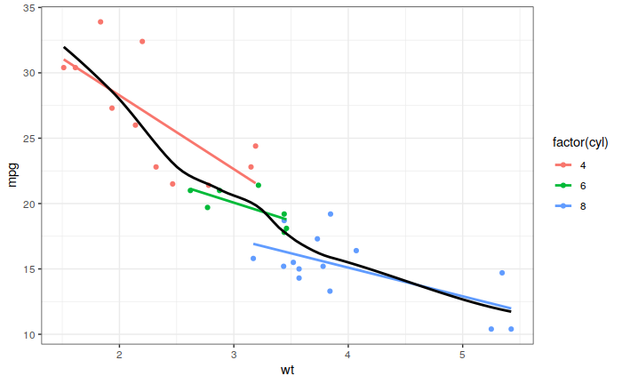

```r
# Plot 2: Set the second stat_smooth() to use LOESS with a span of 0.7
ggplot(mtcars, aes(x = wt, y = mpg, col = factor(cyl))) +
  geom_point() +
  stat_smooth(method = "lm", se = FALSE) +
  stat_smooth(method = "loess", aes(group = 1), se = FALSE, col = "black", span = 0.7) +
  theme_bw()
```

### Adding ‘All’ to the legend and colours

The problem with the plot now however is that the loess model isn’t considered it’s own group which means:

- it won’t appear in the legend
- it won’t behave when feeding colours to the plot

In order to address this:

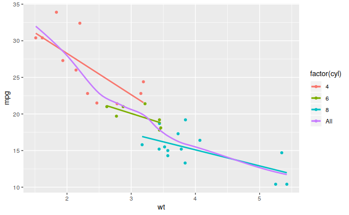

```r
# Plot 3: Set col to "All", inside the aes layer of stat_smooth()
ggplot(mtcars, aes(x = wt, y = mpg, col = factor(cyl))) +
  geom_point() +
  stat_smooth(method = "lm", se = FALSE) +
  stat_smooth(method = "loess",
              # Add col inside aes()
              aes(group = 1, col = "All"),
              # Remove the col argument below
              se = FALSE, span = 0.7)
```

#### Custom Colours

Now the colours look about right we will specify our own colours with by using `RColorBrewer`

First Generate the Vector of colours:

```r
library(RColorBrewer)
myColors <- brewer.pal(4, "Dark2")
```

Now give those colours to the plut by adding a `scale_colour_manual()` layer and specify the name for the colour variable. (The name for the colour variale could also be specified using `labs(col = "Cylinders"))`

```r
# Plot 4: Add scale_color_manual to change the colors
TheMTCarsPlot <- ggplot(mtcars, aes(x = wt, y = mpg, col = factor(cyl))) +
  geom_point() +
  stat_smooth(method = "lm", se = FALSE, span = 0.7) +
  stat_smooth(method = "loess",
              aes(group = 1, col="All"),
              se = FALSE, span = 0.7)+
  theme_bw()
```

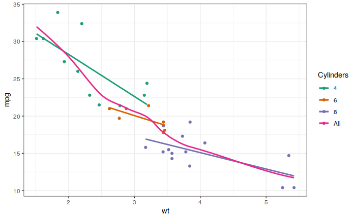

```r
TheMTCarsPlot +
  scale_color_manual("Cylinders", values = myColors)
```

##### Seperate Colour for Loess

If we wanted to specify a particular colour for the loess mode, say for example a blue/grey colour, we could acheive that by adding it to the very end of the colour vector:

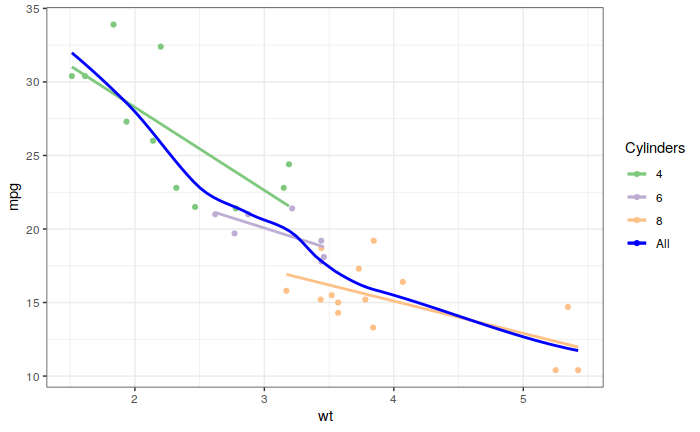

```r
myColors <- c(brewer.pal(n = 3, name = "Accent"), "blue")


TheMTCarsPlot +
  scale_color_manual("Cylinders", values = myColors)
```

# Modifying [`stat_smooth`](https://campus.datacamp.com/courses/data-visualization-with-ggplot2-2/chapter-1-statistics?ex=4)

LOESS smoothing is a non-parametric (Refer to Time Series Analysis) form of regression that uses a weighted, sliding-window, average to calculate a line of best fit, We can control the size of this window with the span argument, by default `stat_smooth` uses the LOESS model.

## Simple Plot

The span of the LOESS model can be changed to some arbitrary number, say 0.7923 by specifying the `span` argument as `span = 0.7923`:

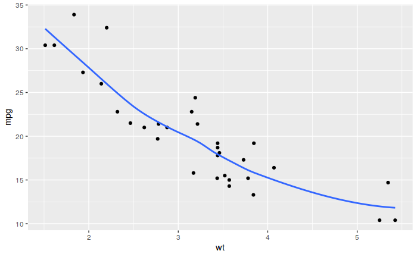

```r
library(ggplot2)
ggplot(mtcars, aes(x = wt, y = mpg)) +
  geom_point() +
  # Add span below
  geom_smooth(se = FALSE, span = 0.7923)
```

## Fitting Models using Stat_Smooth

```r
# Plot 2: Set the second stat_smooth() to use LOESS with a span of 0.7
ggplot(mtcars, aes(x = wt, y = mpg, col = factor(cyl))) +
  geom_point() +
  stat_smooth(method = "lm", se = FALSE) +
  # Change method and add span below
  stat_smooth(method = "loess", aes(group = 1),
              se = FALSE, col = "black")
```

[output not shown]